# Final Project: Stack Overflow Developer Profiles and their Interest in R

Dan Powell

# Questions:

## Which Machine Learning Methods did you Implement?

I implemented PCA with an unsupervised learning technique of hierarchical clustering to better understand the landscape of the data since I believe there to be a hierarchical structure to the data. The next model I used was a lasso regression, which was chosen due to its high performance, interpretability, and ability to automatically reduce dimensionality, as we have many predictors available. Next, I use XGBoost boosted tree model, which allows for the production of feature importance charts and PDP plots while also regularizing the data to prevent overfitting. Finally, I employed a softmax neural network, which is well-suited for handling complex, non-linear relationships between features and the target variable. This model’s ability to handle multiple independent variables without extensive feature engineering makes it a valuable tool for our analysis.

## Discuss the key contribution of each method to your analysis.

Each model contributed new information to our analysis. The PCA and hierarchical clustering in the data seemed to show that there were clear hierarchical relationships among many of the clusters in the data. After clustering the data, we observed distinct differences between the clusters in terms of compensation levels, software development experience, and academic affiliations.

Next, the lasso regression contributed a very detailed view into the coefficient and odds ratios for what the algorithm deemed to be the most impactful predictors. Because of its efficiency, the lasso regression also allowed for us to view some of the specific languages and their relationship with wanting to learn R through the coefficent chart. The XGBoost model’s PDP and feature importance charts also offered key insights into the relationships between the target and predictor variables, confirming many of the observations from the lasso regression. Finally, the neural network, while not able to outperform the XGBoost or lasso regression model, was fit to a much smaller dataset that underwent 42 different combinations hyperparameters in its 5-level and 5-fold cross validation, and still performed well on the training data. This indicates that even if the other two models performed better on the metrics of F1 and accuracy with the test data, the neural network model could become useful if the other two predictive methods show signs of overfitting in real-world application.

## Did all methods support your conclusions or did some provide conflicting results

While the PCA and hierarchical clustering provided a general overview of the data, initial observations revealed that the cluster with the least interest in R also had the highest average compensation, a relatively young demographic, and a significant presence in the software development industry. These findings would be backed by the lasso regression, which also showed that younger populations, those in the software industry, and those with higher compensations had negative relationships with wanting to learn R. The XGBoost model, through its PDP charts, also showed the same relationship for compensation.

# Loading and Cleaning Data

First, we load in our required packages and our raw data.

```r
#Load in required Packages
library(fastDummies)
library(tidyr)
library(dplyr)
library(caret)
library(pROC)
library(corrplot)
library(performanceEstimation)
library(glmnet)
library(rminer)
library(NbClust)

#set working directory
setwd("C:/Users/swimm/Documents/Skool/Machine Learning/Final Project")

#load in data
rawData <- read.csv('survey_results_public.csv')
```

# Data Cleaning and Preparation

First, before running our models, we clean the data through one-hot encoding, grouping together categorical variables of interest, and scaling our numerical variables while eliminating outliers.

## One-Hot Encoding

Our first step in this process is to one-hot encode some of our variables and group some of our variables together into categories for ease of analysis. We also handle nas in these variables by adding them to their own “missing” category.

```r
#this function searches for semi-colons in the data and seperates the values
# between them in order to create unqiue binary columns for interest in specific languages
OneHotEncodeFactor <- function(variable, data, prefix){

data_sep <- separate_rows(data, variable, sep = ";")

one_hot_encoded <- data_sep %>%
  mutate(Value = 1) %>%
  pivot_wider(
    names_from = variable,
    names_prefix = prefix,
    values_from = Value,
    values_fill = list(Value = 0)
  )
return(one_hot_encoded)
}
```

```r
# select specific columns from raw data
one_hot_data <- rawData[, c('ResponseId','LanguageHaveWorkedWith', 'LanguageWantToWorkWith', 'Industry', 'Age', 'Country','EdLevel', 'YearsCode', 'YearsCodePro', 'WorkExp', 'CompTotal', 'DevType', 'AISelect')]
# oe-hot encode language related features
one_hot_data <- OneHotEncodeFactor('LanguageHaveWorkedWith', one_hot_data, "have_worked_with")
one_hot_data <- OneHotEncodeFactor('LanguageWantToWorkWith', one_hot_data, "want_to_work_with")

# impute missing values in Industry with "Missing" category
one_hot_data$Industry[is.na(one_hot_data$Industry)] <- "Missing"

# Create dummy variables for Industry (including the first category)
one_hot_data <- dummy_cols(one_hot_data, select_columns = "Industry", remove_first_dummy = FALSE)

# Create binary feature for younger age groups
one_hot_data <- one_hot_data %>%
  mutate(is_younger = ifelse(Age %in% c("18-24 years old", "25-34 years old"), 1, 0))

# Filter data for US respondents only
one_hot_data <- one_hot_data %>%
  filter(Country == "United States of America")

# Create binary features for education levels
one_hot_data <- one_hot_data %>%
  mutate(advanced_ed = ifelse(EdLevel %in% c("Master’s degree (M.A., M.S., M.Eng., MBA, etc.)", "Professional degree (JD, MD, Ph.D, Ed.D, etc.)"), 1, 0))

one_hot_data <- one_hot_data %>%
  mutate(higher_ed = ifelse(EdLevel %in% c("Bachelor’s degree (B.A., B.S., B.Eng., etc.)", "Associate degree (A.A., A.S., etc.)"), 1, 0))

one_hot_data <- one_hot_data %>%
  mutate(lower_than_higher_ed = ifelse(EdLevel %in% c("Primary/elementary school", "Secondary school (e.g. American high school, German Realschule or Gymnasium, etc.)", "Some college/university study without earning a degree"), 1, 0))

# Convert numeric features to numeric data type
one_hot_data$YearsCode <- as.numeric(one_hot_data$YearsCode)
one_hot_data$YearsCodePro <- as.numeric(one_hot_data$YearsCodePro)
one_hot_data$CompTotal <- as.numeric(one_hot_data$CompTotal)
one_hot_data$WorkExp <- as.numeric(one_hot_data$WorkExp)

# Create binary feature for academic professions
one_hot_data <- one_hot_data %>%
  mutate(academic_prof = ifelse(DevType %in% c("Academic researcher", "Scientist",
                                               "Student"), 1, 0))
# Create binary feature for intention to use AI
one_hot_data <- one_hot_data %>%
  mutate(use_AI = ifelse(AISelect %in% c("Yes", "No, but I plan to soon"), 1, 0))

# Create binary feature for having worked with R
one_hot_data <- one_hot_data %>%
  mutate(have_worked_withR = ifelse(have_worked_withR == 1, 1, 0))

# Create binary feature for wanting to work with R
one_hot_data <- one_hot_data %>%
  mutate(want_to_work_withR = ifelse(want_to_work_withR == 1, 1, 0))
```

## Numerical Data Cleanig

Next, we clean our numerical values through median imputation for nulls.

```r
#rid of extra columns
stg_data <- one_hot_data[, !names(one_hot_data) %in% c("Age", "Industry", "Country", "EdLevel", "DevType", "AISelect")]
#median impute nulls for numerical variables
stg_data <- stg_data %>%
  mutate(
    CompTotal = ifelse(is.na(CompTotal), median(CompTotal, na.rm = TRUE), CompTotal),
    YearsCode = ifelse(is.na(YearsCode), median(YearsCode, na.rm = TRUE), YearsCode),
    YearsCodePro = ifelse(is.na(YearsCodePro), median(YearsCodePro, na.rm = TRUE), YearsCodePro),
    WorkExp = ifelse(is.na(WorkExp), median(WorkExp, na.rm = TRUE), WorkExp)
  )
```

### Outlier Detection

Additionally, we need to check for outliers among our numerical data as well. Here we find some extereme observations for compensation totals, which we eliminate from our dataset.

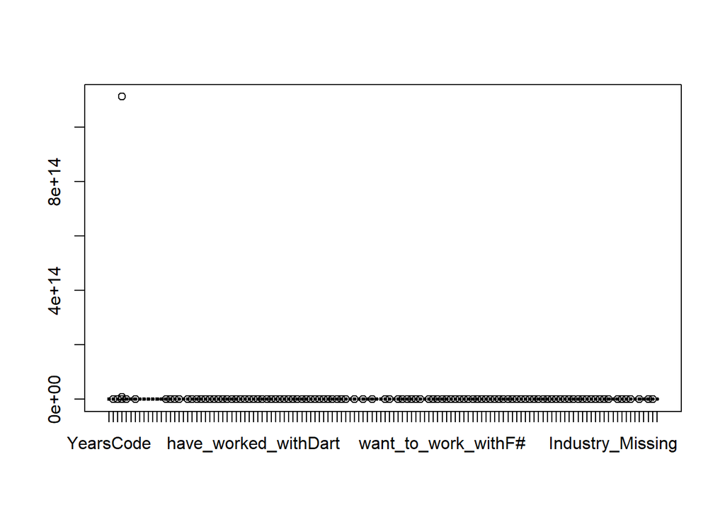

```r
#get boxplots of all the data
boxplot(stg_data[, !names(stg_data) %in% c("ResponseId")])
```

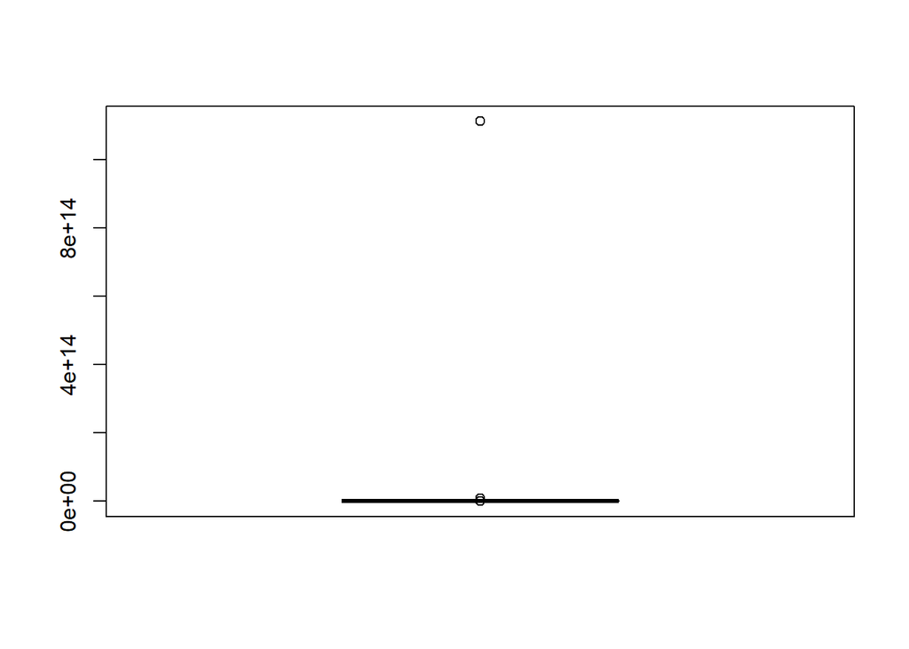

```r
#Focus in on just comp total
boxplot(stg_data[, "CompTotal"])
```

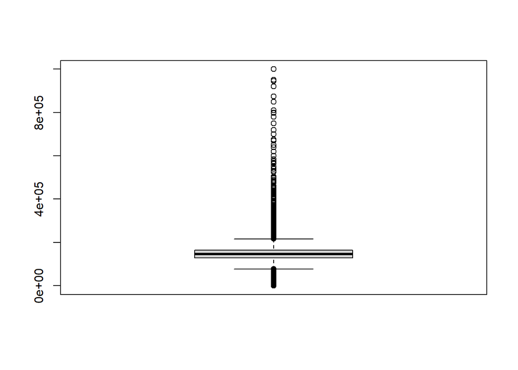

```r
#filter out observations over a million
stg_data <- stg_data %>%
  filter(CompTotal <= 1000000)
#check boxplot again for compensation ater filtering
boxplot(stg_data[, "CompTotal"])
```

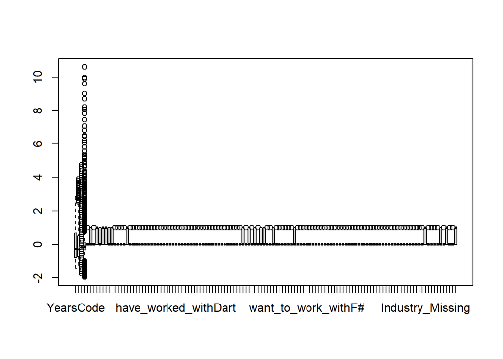

```r
#scale numerical variables to prevent bias
final_Data <- stg_data %>%
  mutate(across(c("WorkExp", "CompTotal", "YearsCodePro", "YearsCode"), scale))
#check distribution among variables again
boxplot(final_Data[,!names(final_Data) %in% c("ResponseId")])
```

```r
colnames(final_Data) <- make.names(colnames(final_Data), unique = TRUE)
```

# Unsupervised Clustering with PCA

The first step of our analysis will be to investigate the overall landscape of the data through hierarchical clustering. Hierarchical clustering was chosen due to its ability to determine the optimal number of clusters by itself and since we suspect that there may be a hierarchical relationship in our data (for an example, you may see a split for more experienced developers that then branches into those who work with data science, full stack developers, etc.)

## Setup for Clustering with PCA

First, we will load in our packages:

```r
library(cluster)
library(circlize)
library(dendextend)
library(gplots)
library(NbClust)
```

## PCA

Before clustering, we will first transform our data into its principle components. This will reduce the dimenisonality of our data and hopefully speed up the process of analysis while focusing on the components that capture the most variance in our data.

```r
set.seed(123)
#get just numeric values
justnumsData <- final_Data[, -1]
#randomly sample data  for just 5000 obs due to performance concerns
justnumsData <- sample_n(justnumsData, 5000)

#convert to numeric
justnumsData[] <- lapply(justnumsData, function(x) as.numeric(as.character(x)))

#Calculate variance-covariance mix
cov_w <- cov(justnumsData)

#get eigenvalues and eigen vectors
e_w <- eigen(cov_w)
eigenval <- e_w$values
eigenvec <- e_w$vectors
#estimate percent of variance explained
var_exp <- round(eigenval/sum(eigenval),3)
#get cumulative variance explained by each component
cumu_var <- cumsum(var_exp)
print(cumu_var) #first
```

```
##   [1] 0.199 0.280 0.346 0.394 0.432 0.465 0.494 0.522 0.546 0.568 0.589 0.608
##  [13] 0.626 0.644 0.660 0.675 0.689 0.702 0.714 0.725 0.735 0.745 0.755 0.764
##  [25] 0.773 0.782 0.790 0.798 0.805 0.812 0.818 0.824 0.830 0.836 0.842 0.848
##  [37] 0.853 0.858 0.863 0.868 0.873 0.877 0.881 0.885 0.889 0.893 0.897 0.901
##  [49] 0.904 0.907 0.910 0.913 0.916 0.919 0.922 0.925 0.928 0.931 0.933 0.935
##  [61] 0.937 0.939 0.941 0.943 0.945 0.947 0.949 0.951 0.953 0.955 0.957 0.959
##  [73] 0.961 0.963 0.965 0.967 0.968 0.969 0.970 0.971 0.972 0.973 0.974 0.975
##  [85] 0.976 0.977 0.978 0.979 0.980 0.981 0.982 0.983 0.984 0.985 0.986 0.987
##  [97] 0.988 0.989 0.990 0.991 0.992 0.993 0.994 0.995 0.996 0.997 0.998 0.999
## [109] 1.000 1.001 1.001 1.001 1.001 1.001 1.001 1.001 1.001 1.001 1.001 1.001
## [121] 1.001 1.001 1.001 1.001 1.001 1.001
```

It looks like a lot of our variables contribute to the top 90% of variance, specifically the first 50 or so. We’ll narrow down a bit for performance sake and just get 80% of the variance, which will be the top 29 variables. Next, we will use matrix multiplication to test for correlation in our eigenvector.

```r
set.seed(123)
#convert to matrix
justnumsDatamatrix <- as.matrix(justnumsData)
#Just use first 7 for matrix multiplication
pca_w <- justnumsDatamatrix %*% eigenvec[,-c(29:126)]

#test for correlation in the data, then calculate the new variance-covariance mix
print(round(cor(pca_w),3)) # uncorrelated
```

```
##       [,1] [,2] [,3] [,4] [,5] [,6] [,7] [,8] [,9] [,10] [,11] [,12] [,13]
##  [1,]    1    0    0    0    0    0    0    0    0     0     0     0     0
##  [2,]    0    1    0    0    0    0    0    0    0     0     0     0     0
##  [3,]    0    0    1    0    0    0    0    0    0     0     0     0     0
##  [4,]    0    0    0    1    0    0    0    0    0     0     0     0     0
##  [5,]    0    0    0    0    1    0    0    0    0     0     0     0     0
##  [6,]    0    0    0    0    0    1    0    0    0     0     0     0     0
##  [7,]    0    0    0    0    0    0    1    0    0     0     0     0     0
##  [8,]    0    0    0    0    0    0    0    1    0     0     0     0     0
##  [9,]    0    0    0    0    0    0    0    0    1     0     0     0     0
## [10,]    0    0    0    0    0    0    0    0    0     1     0     0     0
## [11,]    0    0    0    0    0    0    0    0    0     0     1     0     0
## [12,]    0    0    0    0    0    0    0    0    0     0     0     1     0
## [13,]    0    0    0    0    0    0    0    0    0     0     0     0     1
## [14,]    0    0    0    0    0    0    0    0    0     0     0     0     0
```

[output cut: 72 more lines]

From the output, we can see that the correlation between the variables is minimal. Now lets move onto our linkage methods to finishing our clustering analysis.

## Trying different linkage methods

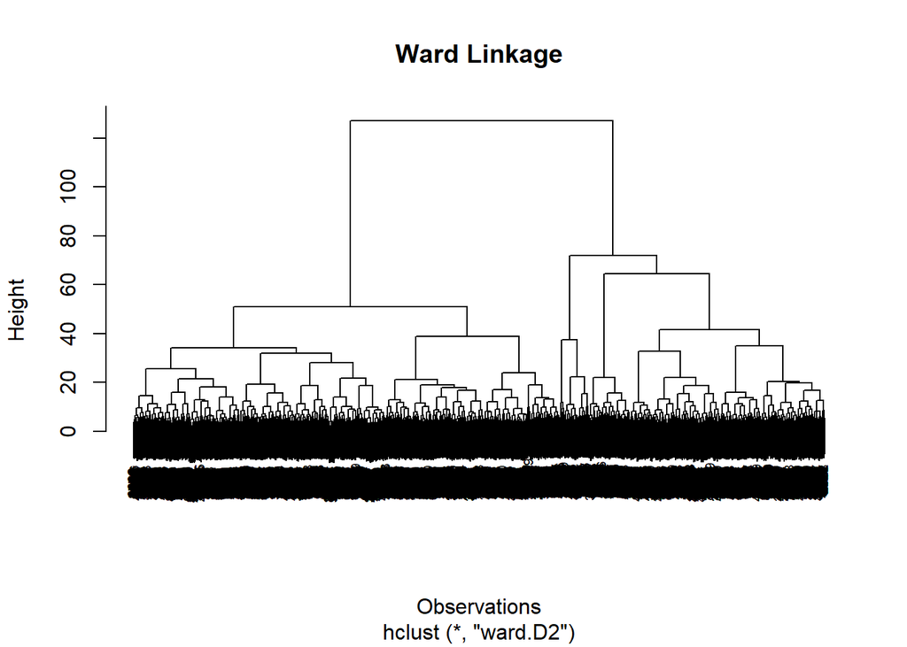

```r
#get pca distances using euclidean distance
d <- dist(pca_w, method = "euclidean")
#use ward method for dendrogram
fit.w <- hclust(d,method="ward.D2")
#plot dendrogram for ward linkage
plot(fit.w, main = "Ward Linkage", xlab = "Observations", ylab = "Height", cex = .6)
```

It looks like we have many clusters here, but can observe the main cutoffs seem to occur around ~50. Let’s try an average linkage to see if that produces better results:

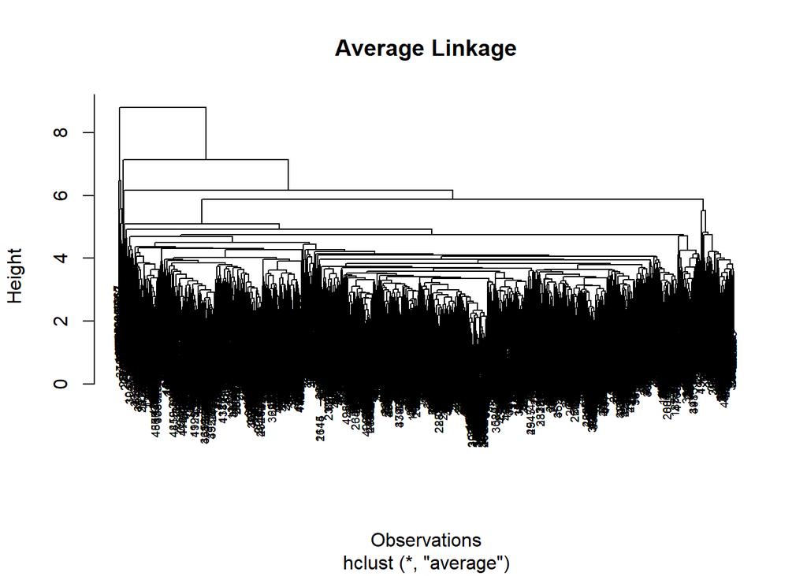

```r
set.seed(123)
#use ward method for dendrogram
fit.a <- hclust(d,method="average")
#plot dendrogram for average linkage
plot(fit.a, main = "Average Linkage", xlab = "Observations", ylab = "Height", cex = .6)
```

From the average linkage, we can see that the main split seems to occur around a height of 9, with a small group of likely outliers separated from a larger division of splits. We will now proceed to our final dendrogram utilizing the complete linkage method.

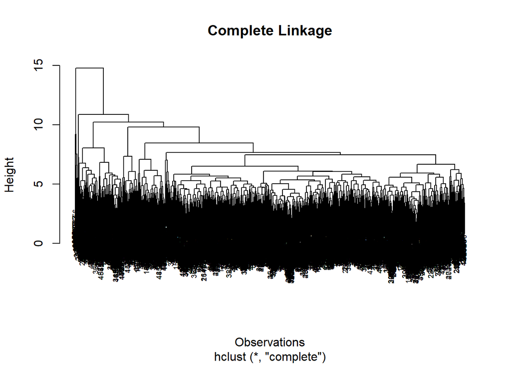

```r
set.seed(123)
#use complete method for dendrogram
fit.c <- hclust(d,method="complete")
#plot complete dendrogram
plot(fit.c, main = "Complete Linkage", xlab = "Observations", ylab = "Height", cex = .6)
```

The chart still looks pretty messy, but there are still clear splits in the data. Let’s check our cophenetic correlation coefficients to see which of the linkage methods performs best.

```r
set.seed(123)
d.coph <- cophenetic(fit.w) # ward linkage
cat('Wards Linkage', cor(d, d.coph))
```

```
## Wards Linkage 0.4321144
```

```r
d.coph <- cophenetic(fit.a) # average linkage
cat('\nAverage Linkage', cor(d, d.coph))
```

```
##
## Average Linkage 0.7395169
```

```r
d.coph <- cophenetic(fit.c) # complete linkage
cat('\nComplete Linkage', cor(d, d.coph))
```

```
##
## Complete Linkage 0.6753164
```

Of the three linkage methods, the average linkage method seemed to produce the highest cophenetic correlation coefficient at 0.739. However, it also seemed to have the produce branches that seemed influenced the most by outliers in the data due to the small branch at the top of the data. Complete linkage method, however, is more robust to outliers compared to the average method. As we are looking to gather an overall view of the data, we will proceed with using the complete method instead.

## Dividing the Clusters with the PCA Data

To investigate the characteristics within each cluster, we will first use the PCA data with the complete linkage method to get the best number of clusters.

```r
set.seed(123)
# Perform NbClust analysis to find the optimal number of clusters using silhouette for performance
res<-NbClust(pca_w, distance = "euclidean", min.nc=2, max.nc=10,
method = "complete", index = "silhouette")

# Extract the best number of clusters based on the silhouette index
cat('Best Number of Clusters:', res$Best.nc)
```

```
## Best Number of Clusters: 2 0.4881
```

```r
# Cluster the data using complete's method
justnumsData$clusters <- cutree(fit.c, 2)
# Print the frequency table of cluster assignments for 2 clusters
table(justnumsData$clusters)
```

```
##
##    1    2
## 4960   40
```

```r
justnumsData$clusters <- cutree(fit.c, 10)
table(justnumsData$clusters)
```

```
##
##    1    2    3    4    5    6    7    8    9   10
##  348 3783  311  196  251   30   62    6    9    4
```

While 2 clusters seemed to be the best split, it mostly seems to just show us a smaller group of potentially outliers and the rest of the data. For this reason, we will increase the cut level to 10 and examine the top 5 clusters with significant populations.

## Stats on two largest groups

```r
filtered_data <-subset(justnumsData, clusters == 1 | clusters == 2| clusters == 3 | clusters == 4 | clusters == 5)
#Get means and standard deviations across variables between the two larger clusters
summary_by_cluster <- filtered_data %>%
  group_by(clusters) %>%
  summarize(across(everything(), list(mean = mean, sd = sd), .names = "{.col}_{.fn}"))
summary_by_cluster <- as.data.frame(t(summary_by_cluster))
#get delta between the value of the metric between the two clusters
summary_by_cluster$diff <- abs(summary_by_cluster$V1- summary_by_cluster$V2)
summary_by_cluster <- summary_by_cluster %>%
  arrange(desc(diff))
#display the cluster (only displaying head for formatting purposes)
print(head(summary_by_cluster))
```

```
##                               V1         V2         V3          V4         V5
## WorkExp_mean          1.54214342 -0.3227466 -0.0456834 -0.05740619 2.85444329
## YearsCode_mean        0.83649538 -0.3591951  1.6739791 -0.04143171 1.85326006
## YearsCodePro_mean     0.77993745 -0.3885536  1.9564625 -0.07146048 2.12226247
## clusters              1.00000000  2.0000000  3.0000000  4.00000000 5.00000000
## is_younger_mean       0.01149425  0.5424266  0.0000000  0.50000000 0.00000000
## Industry_Missing_mean 0.04885057  0.5440127  0.9324759  0.36734694 0.01195219
##                            diff
## WorkExp_mean          1.8648901
## YearsCode_mean        1.1956905
## YearsCodePro_mean     1.1684910
## clusters              1.0000000
## is_younger_mean       0.5309324
## Industry_Missing_mean 0.4951621
```

# Lasso Regression

The first predictive model chosen was a Lasso regression. A lasso regression suits our data well as it is able to reduce the dimensionality of the data to the most impactful variables and is not computationally intensive.

## Setup Train and Test

```r
set.seed(123)

#get index to divide data into training and test sets
index <- createDataPartition(final_Data$want_to_work_withR, p = 0.8, list = FALSE)
#create training and test sets
train_data <- final_Data[index,]
test_data <- final_Data[-index,]
#ensure variables are numeric
train_data[] <- lapply(train_data, as.numeric)
#factor target variable
train_data$want_to_work_withR <- as.factor(train_data$want_to_work_withR)
print('Pre-SMOTE')
```

```
## [1] "Pre-SMOTE"
```

```r
print(table(train_data$want_to_work_withR))
```

```
##
##    0    1
## 8440  423
```

```r
#balance classes using SMOTE
SmoteTrainData <- smote(want_to_work_withR ~ ., data = train_data, perc.over = 2)
#produce post-SMOTE data
print('Post-SMOTE')
```

```
## [1] "Post-SMOTE"
```

```r
print(table(SmoteTrainData$want_to_work_withR))
```

```
##
##    0    1
## 1692 1269
```

## Fit Lasso Model

Next, to fit our lasso model we use cross validation with an MSE measure to determine the best level of lambda for our model.

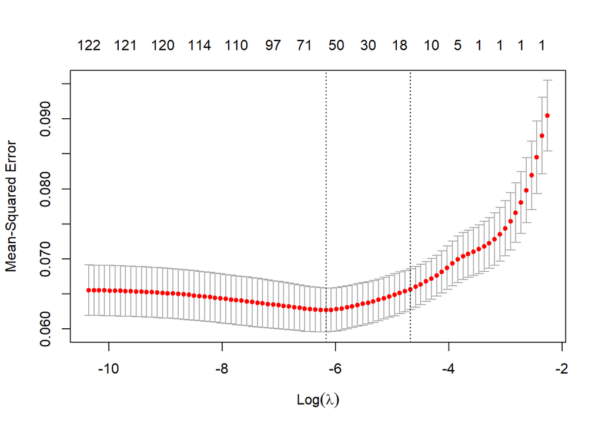

```r
set.seed(123)
#get our x and y variables assigned
x <- data.matrix(train_data[, !names(final_Data) %in% c("ResponseId" ,"want_to_work_withR")])
y <- train_data$want_to_work_withR
#fit lasso model to get best lambda in 5 fold cv
cv.lasso <- cv.glmnet(x, y, alpha = 1, nfolds = 5, type.measure = "mse", standardize=TRUE,family='binomial')
#plot the model
plot(cv.lasso)
```

## Optimal Lambda Value and Coefficient Estimates

```r
set.seed(123)
#get best lambda from cross validation
best_lambda <- cv.lasso$lambda.min
cat('Best Lambda:', best_lambda)
```

```
## Best Lambda: 0.002094232
```

```r
#get coefficent estimates from model using best lambda and print
coefficients <- coef(cv.lasso, s="lambda.min", exact=FALSE)
#Get number of coefficents eliminated by lasso
zero_coeffs <- sum(coefficients [-1] == 0)
cat('\nNumber of Eliminatted Coefficents: ', zero_coeffs, '\n')
```

```
##
## Number of Eliminatted Coefficents:  69
```

```r
# Create a data frame with the variable names and their corresponding coefficients
coefficients_values <- as.vector(coefficients)
coeff_names <- rownames(coefficients)
coefficients_df <- data.frame(
  Variable = coeff_names,
  Coefficient = coefficients_values,
  stringsAsFactors = FALSE
)

# Remove the intercept (optional, assuming intercept is the first entry)
coefficients_df <- coefficients_df[-1,]  # Exclude intercept (first row)

# Remove any rows where the coefficient is zero (optional)
coefficients_df <- coefficients_df[coefficients_df$Coefficient != 0, ]
coefficients_df$OddsRatio <- exp(coefficients_df$Coefficient)
# Sort the coefficients from largest to smallest by absolute value
sorted_coefficients_df <- coefficients_df[order(-abs(coefficients_df$Coefficient)), ]

# Print the sorted coefficients data frame
print(sorted_coefficients_df)
```

```
##                                     Variable   Coefficient  OddsRatio
## 23                         have_worked_withR  3.3861174537 29.5509961
## 56                       want_to_work_withNA -1.2488191700  0.2868433
## 86                    want_to_work_withCobol  1.0639809289  2.8978843
## 71                  want_to_work_withCrystal  0.9490337065  2.5832123
## 74                      want_to_work_withVBA  0.9244857697  2.5205718
## 103                  want_to_work_withZephyr  0.9104313221  2.4853943
## 38                   have_worked_withCrystal -0.8592224841  0.4234912
## 97                   want_to_work_withMATLAB  0.7678218865  2.1550672
## 63                   want_to_work_withPython  0.6756097288  1.9652309
## 78                  want_to_work_withClojure  0.6100387795  1.8405028
## 55                    have_worked_withZephyr  0.5834098378  1.7921389
## 43                       have_worked_withAda -0.5599972834  0.5712106
## 90                     want_to_work_withLisp  0.5535147050  1.7393556
## 67                      want_to_work_withSQL  0.5351504322  1.7077051
```

[output cut: 42 more lines]

We can also see some of the most impactful variables with sorting the output from our lasso function. Here it looks like those who have worked with R are more likely to want to continue working with it, which may be somewhat intuitive. Additionally, we can see that wanting to work languages like MATLAB, Cobol, Crystal, and VBA also can include the survey user wanting to use R as well - which makes sense as these are also often used in more scientific or analytical studies rather than application development or other software engineering fields. Interestingly, working with many of the functional languages such as Crystal, Ada, and Go were associated with less of an interest in R. Other than specific languages, we can see that Fintech and software development industries showed less of an interest in R compared to those in government or healthcare industries. Additionally, those with advanced degrees or in academic professions seemed to want to learn R compared to those with a bachelor’s degree or lower who seemed less interested in the language.

## Testing the Linear Model

Before we argue for the significance of these coefficents, let’s first check the performance of the model on the test data to see if it can accurately predict whether a user will be interested in R.

```r
set.seed(123)
#get x and y variables from test data
X_test <- as.matrix(test_data[, -which(names(test_data) %in% c("want_to_work_withR", "ResponseId"))])
y_test <- test_data$want_to_work_withR
#get predicted values using our model
predictions <- predict(cv.lasso, s = "lambda.min", newx = X_test, type = "response")
# Convert the probabilities to binary outcomes (threshold at 0.5)
predicted_classes <- ifelse(predictions > 0.5, 1, 0)

# Evaluate performance: Accuracy
accuracy <- mean(predicted_classes == y_test)
print(paste("Accuracy:", accuracy))
```

```
## [1] "Accuracy: 0.965237020316027"
```

```r
# Confusion Matrix
confusionMatrix <- confusionMatrix(data = factor(predicted_classes), reference = factor(y_test))
print(confusionMatrix$table)
```

```
##           Reference
## Prediction    0    1
##          0 2112   58
##          1   19   26
```

```r
accuracy <- confusionMatrix$overall['Accuracy']
precision <- confusionMatrix$byClass['Precision']
recall <- confusionMatrix$byClass['Sensitivity']
f1_score <- 2 * (precision * recall) / (precision + recall)

# Calculate AUC-ROC
roc_curve <- roc(y_test, predictions)
auc_value <- auc(roc_curve)
print(paste("AUC-ROC:", auc_value))
```

```
## [1] "AUC-ROC: 0.861676275390494"
```

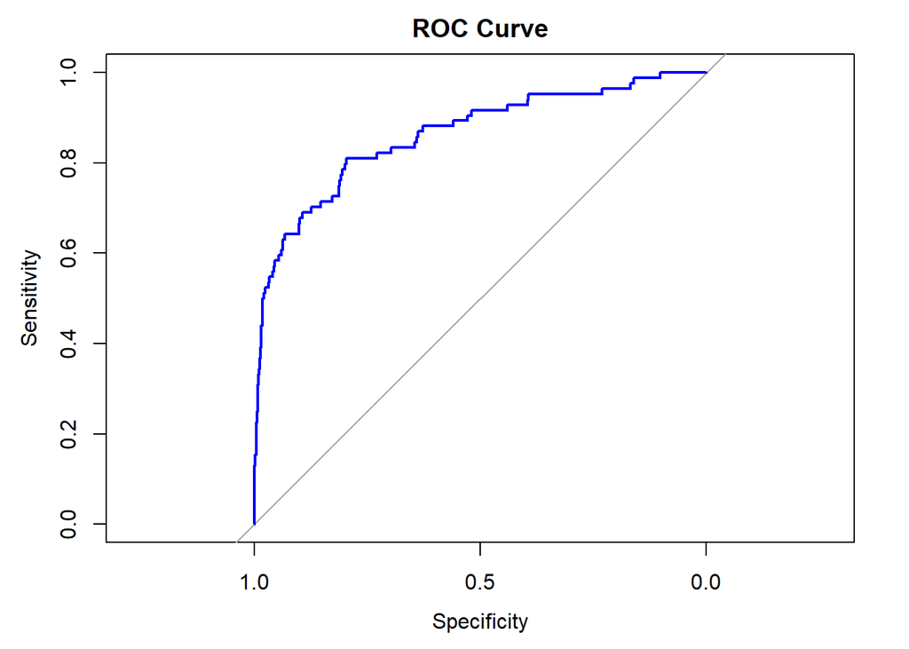

```r
# Plot ROC curve
plot(roc_curve, main = "ROC Curve", col = "blue")
```

```r
print(paste("Accuracy:", round(accuracy,4)))
```

```
## [1] "Accuracy: 0.9652"
```

```r
print(paste("Precision:", round(precision,4)))
```

```
## [1] "Precision: 0.9733"
```

```r
print(paste("Recall:", round(recall,4)))
```

```
## [1] "Recall: 0.9911"
```

```r
print(paste("F1-Score:", round(f1_score,4)))
```

```
## [1] "F1-Score: 0.9821"
```

Next, we will expand on our analysis’ robustness by utilizing a boosted tree model.

# Boosted Tree Model: XGBoost

Our next model will utilize the boosted tree model, XGBoost. This model was chosen due to its ability to model complex relationships, produce high accuracy relationships, and produce feature importance and PDP charts which we can use to determine if our findings from the lasso regression are consistent across models.

```r
#loadi in all packages for XGBoost Model
library(httr)
library(jsonlite)
library(dplyr)
library(forcats)
library(tidymodels)
library(lubridate)
library(stringr)
library(yardstick)
library(xgboost)
library(dplyr)
library(doParallel)
library(caret)
library(performanceEstimation)
```

## Altering Data for Complex Models

Before proceeding, through trail and error, we determined that the original dataset is too complex to be used with our XGboost model. In order to remedy this, we lowered the dimensionality by creating categories of interest among the programming language variables. Now, instead of seperate variables for wanting to work with and having worked with a language, there is just one variable to represent interest. On top of this, these interests are grouped into categories of languages, so instead of naming a language specifically, we will show a binary indicator whether that user has an interest a subgenre of programming languages such as Data science languages, functional concurrent, languages, etc. The language categories were chosen by AI, as sorting through over 100 languages available to chose from and accurately categorizing them is beyond the skillset of the author. Finally, we take a subset of 7000 observations of our original dataset for perfromance concerns. This subset is randomly selected in order to prevent bias.

```r
set.seed(123)
BaggingData_copy <- final_Data


# 1. Data Science/Analysis Languages
BaggingData_copy$Data_Science_Languages <- as.integer( BaggingData_copy$have_worked_withPython |BaggingData_copy$want_to_work_withPython | BaggingData_copy$want_to_work_withMicroPython | BaggingData_copy$have_worked_withMicroPython |BaggingData_copy$have_worked_withMATLAB | BaggingData_copy$want_to_work_withMATLAB)

# 2. Application Development Languages
BaggingData_copy$Application_Development_Languages <- as.integer(BaggingData_copy$have_worked_withGo | BaggingData_copy$have_worked_withC. | BaggingData_copy$want_to_work_withC. |BaggingData_copy$have_worked_withPython |BaggingData_copy$want_to_work_withPython  |  BaggingData_copy$want_to_work_withTypeScript |   BaggingData_copy$have_worked_withTypeScript | BaggingData_copy$have_worked_withRust |BaggingData_copy$have_worked_withScala | BaggingData_copy$have_worked_withRuby |BaggingData_copy$have_worked_withJava | BaggingData_copy$have_worked_withKotlin | BaggingData_copy$have_worked_withLua | BaggingData_copy$have_worked_withObjective.C | BaggingData_copy$have_worked_withElixir | BaggingData_copy$have_worked_withPerl | BaggingData_copy$have_worked_withClojure | BaggingData_copy$have_worked_withZig | BaggingData_copy$have_worked_withCrystal | BaggingData_copy$have_worked_withAda | BaggingData_copy$want_to_work_withRust |BaggingData_copy$want_to_work_withScala | BaggingData_copy$want_to_work_withRuby |BaggingData_copy$want_to_work_withJava | BaggingData_copy$want_to_work_withKotlin |BaggingData_copy$want_to_work_withLua | BaggingData_copy$want_to_work_withObjective.C |BaggingData_copy$want_to_work_withElixir | BaggingData_copy$want_to_work_withPerl |BaggingData_copy$want_to_work_withClojure | BaggingData_copy$want_to_work_withZig |BaggingData_copy$want_to_work_withCrystal | BaggingData_copy$want_to_work_withAda |BaggingData_copy$want_to_work_withLisp     |    BaggingData_copy$have_worked_withLisp
  )

# 3. Database/Query Languages
BaggingData_copy$Database_Query_Languages <- as.integer(BaggingData_copy$have_worked_withSQL | BaggingData_copy$want_to_work_withSQL)

# 4. Scripting Languages/Tools
BaggingData_copy$Scripting_Languages_Tools <- as.integer(BaggingData_copy$want_to_work_withBash.Shell..all.shells. | BaggingData_copy$want_to_work_withPowerShell |BaggingData_copy$want_to_work_withZephyr | BaggingData_copy$have_worked_withVBA | BaggingData_copy$have_worked_withGDScript | BaggingData_copy$want_to_work_withGDScript |BaggingData_copy$want_to_work_withVBA |BaggingData_copy$want_to_work_withLua | BaggingData_copy$have_worked_withLua | BaggingData_copy$have_worked_withBash.Shell..all.shells. | BaggingData_copy$have_worked_withPowerShell | BaggingData_copy$have_worked_withZephyr )

# 5. Legacy/Classic Languages
BaggingData_copy$Legacy_Classic_Languages <- as.integer(BaggingData_copy$have_worked_withAssembly | BaggingData_copy$have_worked_withCobol |BaggingData_copy$have_worked_withFortran | BaggingData_copy$want_to_work_withCobol |BaggingData_copy$want_to_work_withFortran | BaggingData_copy$want_to_work_withAssembly )

# 6. Functional & Concurrent Languages
BaggingData_copy$Functional_Concurrent_Languages <- as.integer(BaggingData_copy$have_worked_withScala | BaggingData_copy$have_worked_withElixir |
                                                                BaggingData_copy$have_worked_withClojure | BaggingData_copy$want_to_work_withScala |
                                                                BaggingData_copy$want_to_work_withElixir | BaggingData_copy$want_to_work_withClojure | BaggingData_copy$have_worked_withErlang |
                                                                BaggingData_copy$want_to_work_withErlang)

# 7. Emerging/Unconventional Languages
BaggingData_copy$Emerging_Unconventional_Languages <- as.integer(BaggingData_copy$have_worked_withZephyr | BaggingData_copy$have_worked_withAda | BaggingData_copy$want_to_work_withAda |
BaggingData_copy$want_to_work_withGDScript   |                                                               BaggingData_copy$have_worked_withGDScript | BaggingData_copy$want_to_work_withZephyr |BaggingData_copy$want_to_work_withApex | BaggingData_copy$have_worked_withApex |  BaggingData_copy$want_to_work_withJulia | BaggingData_copy$have_worked_withJulia |BaggingData_copy$want_to_work_withZig | BaggingData_copy$have_worked_withZig)

# 8. Miscellaneous/Uncategorized
BaggingData_copy$Missing_language <- as.integer(BaggingData_copy$want_to_work_withNA)

#select columns for analysis
BaggingData_copy <- BaggingData_copy %>%
  select(Data_Science_Languages,
         Application_Development_Languages,
         Database_Query_Languages,
         Scripting_Languages_Tools,
         Legacy_Classic_Languages,
         Functional_Concurrent_Languages,
         Emerging_Unconventional_Languages,
         Missing_language,
         YearsCode,
          YearsCodePro,
        WorkExp,
        CompTotal,
         is_younger
        , advanced_ed
        , higher_ed
        , lower_than_higher_ed
        , academic_prof
        , use_AI,
        Industry_Banking.Financial.Services,
    Industry_Computer.Systems.Design.and.Services,
    Industry_Energy,
    Industry_Fintech,
    Industry_Government,
    Industry_Healthcare,
    Industry_Higher.Education,
    Industry_Insurance,
    Industry_Internet..Telecomm.or.Information.Services,
    Industry_Manufacturing,
    Industry_Media...Advertising.Services,
    Industry_Missing,
    Industry_Other.,
    Industry_Retail.and.Consumer.Services,
    Industry_Software.Development,
    Industry_Transportation..or.Supply.Chain
        , want_to_work_withR
    , have_worked_withR
         )

#train-test split
split <- initial_split(BaggingData_copy, prop = 0.8, strata = want_to_work_withR)

train_data <- training(split)
test_data <- testing(split)
train_data[] <- lapply(train_data, as.numeric)
test_data[] <- lapply(test_data, as.numeric)



#Reduce Number of Variables further by grouping:


train_data$want_to_work_withR <- as.factor(train_data$want_to_work_withR)
train_data <- sample_n(train_data, 7000)
#SMOTE
cat('Before SMOTE:\n', table(train_data$want_to_work_withR ))
```

```
## Before SMOTE:
##  6669 331
```

```r
SmoteTrainData <- smote(want_to_work_withR ~ ., data = train_data, perc.over = 10, perc.under = 1.1)

cat('\nAfter SMOTE:\n\n')
```

```
##
## After SMOTE:
```

```r
print(table(SmoteTrainData$want_to_work_withR))
```

```
##
##    0    1
## 3641 3641
```

Now that we have prepped our data for the XGBoost model, we can fit our models through cross validation utilizing a grid search to chose the optimal hyperparameters to maximize performance on F-measure.

## Recipe for Ensemble Method

```r
set.seed(123)
rec_wantR <- recipe(want_to_work_withR~., SmoteTrainData) #train model using smote data using churn as target and all other variables as predictors
#define model
model_wantR <- boost_tree( #use boosted tree
  trees = tune(), #tune number of trees through grid search
  tree_depth = tune(), #tune tree_depth through grid search
  learn_rate = tune()) %>% #tune learning rate through grid search
    set_engine('xgboost', verbosity = 1) %>% #use xgboost as engine
    set_mode("classification") #model type set to classification
#specify hyperparameter gird to do 2 level grid search through the 3 hyperparameters
hyper_grid <- grid_regular(
  trees(), tree_depth(), learn_rate(), levels=2
)
#Set 5 fold cross validation
want_R_folds <- vfold_cv(SmoteTrainData, v=5)

#Define workflow for the model by adding the recipe and the model to the workflow object
wantR_wf <- workflow() %>%
  add_model(model_wantR) %>%
  add_recipe(rec_wantR)

#set up computer to use parallelism to increase performance
doParallel::registerDoParallel(cores=4)
# set seed for replication

#Start runing through cross validation and model fitting to get best hyperparameters
wantR_tune <- wantR_wf %>%
  tune_grid(
  resamples = want_R_folds,
  grid=hyper_grid,
  metrics = metric_set(f_meas) #return f-measure each iteration
  )


#get all the metrics from the iterations
best_metric <- collect_metrics(wantR_tune)

# Select the best hyperparameters to use
best_index <- which.max(best_metric$mean)
best_params <- best_metric[best_index, ]

# Finalize the workflow with the best parameters
final_wf <- finalize_workflow(wantR_wf, best_params)

# Fit the final model to the training data
final_fit <- fit(final_wf, data = SmoteTrainData)

#make predictions
predictions <- predict(final_fit, new_data = test_data)
#create confusion matrix
confusionMatrix <- confusionMatrix(as.factor(test_data$want_to_work_withR), predictions$.pred_class)
#get accuracy, percision, recall, and F1 score from confusion matrix for our optimal model
accuracy <- confusionMatrix$overall['Accuracy']
precision <- confusionMatrix$byClass['Precision']
recall <- confusionMatrix$byClass['Sensitivity']
f1_score <- 2 * (precision * recall) / (precision + recall)
#Output performance metrics
print(paste("Accuracy:", accuracy))
```

```
## [1] "Accuracy: 0.947202166064982"
```

```r
print(paste("Precision:", precision))
```

```
## [1] "Precision: 0.967544684854186"
```

```r
print(paste("Recall:", recall))
```

```
## [1] "Recall: 0.977197149643705"
```

```r
print(paste("F1-Score:", f1_score))
```

```
## [1] "F1-Score: 0.972346962892933"
```

```r
print(confusionMatrix)
```

```
## Confusion Matrix and Statistics
##
##           Reference
## Prediction    0    1
##          0 2057   69
##          1   48   42
##
##                Accuracy : 0.9472
##                  95% CI : (0.9371, 0.9561)
##     No Information Rate : 0.9499
##     P-Value [Acc > NIR] : 0.73949
##
##                   Kappa : 0.3906
##
##  Mcnemar's Test P-Value : 0.06446
##
##             Sensitivity : 0.9772
##             Specificity : 0.3784
##          Pos Pred Value : 0.9675
##          Neg Pred Value : 0.4667
##              Prevalence : 0.9499
##          Detection Rate : 0.9282
##    Detection Prevalence : 0.9594
##       Balanced Accuracy : 0.6778
##
##        'Positive' Class : 0
##
```

## Feature Importance

Next, we will investigate the feature importance and PDP charts to get an idea of what features contributed the most to the model and to what magnitude.

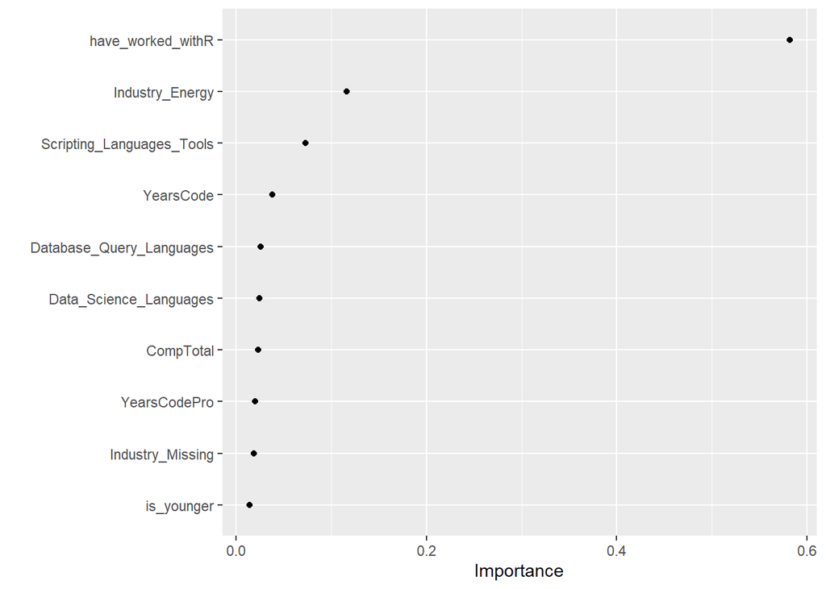

```r
#load in library for  feature importance chart
library(vip)
set.seed(123)
#create feature importance chart
final_wf %>%
  fit(data = SmoteTrainData) %>%
  extract_fit_parsnip() %>%
  vip(geom = "point")
```

From this we can see significant impacts to the model from having worked with R, working in the Energy Industry, and Scripting Language tools. Also of interest is the is_younger variable, comptotal, and database query languages, as they could provide insights into opportunity areas where the R community can grow.

## PDP Charts

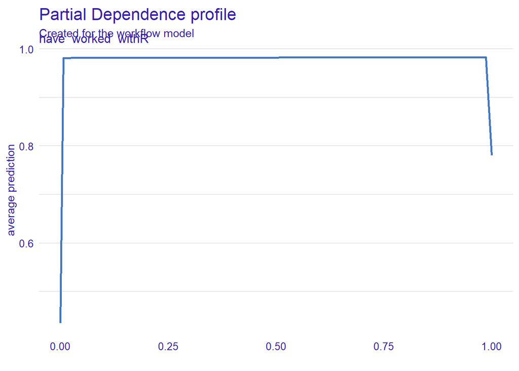

```r
#install.packages('DALEXtra')
library(DALEXtra)
set.seed(123)

#fit the model on the training data to use in pdp analysis
model_fitted <- final_wf %>%
  fit(data = SmoteTrainData)
#create explain object to get relations hips in data
explainer_rf <- explain_tidymodels(model_fitted,
                                   data = SmoteTrainData,
                                   y = SmoteTrainData$want_to_work_withR,
                                   type = "pdp", verbose=FALSE)
#create pdp plots for top few variables of interest
pdp_Data_Science_Languages <- model_profile(explainer_rf,
                                  variables = "Industry_Energy"
                                  , N=NULL)
pdp_Data_Query_lang <- model_profile(explainer_rf,
                                  variables = "Database_Query_Languages"
                                  , N=NULL)
pdp_Script <- model_profile(explainer_rf,
                                  variables = "Scripting_Languages_Tools"
                                   , N=NULL)

pdp_is_younger <- model_profile(explainer_rf,
                                  variables = "is_younger"
                                   , N=NULL)
pdp_Comp_total <- model_profile(explainer_rf,
                                  variables = "CompTotal"
                                   , N=NULL)

pdp_DS_Language<- model_profile(explainer_rf,
                                  variables = "Data_Science_Languages"
                                   , N=NULL)

pdp_worked_with_R <- model_profile(explainer_rf,
                                  variables = "have_worked_withR"
                                   , N=NULL)

#display plots
plot(pdp_worked_with_R)
```

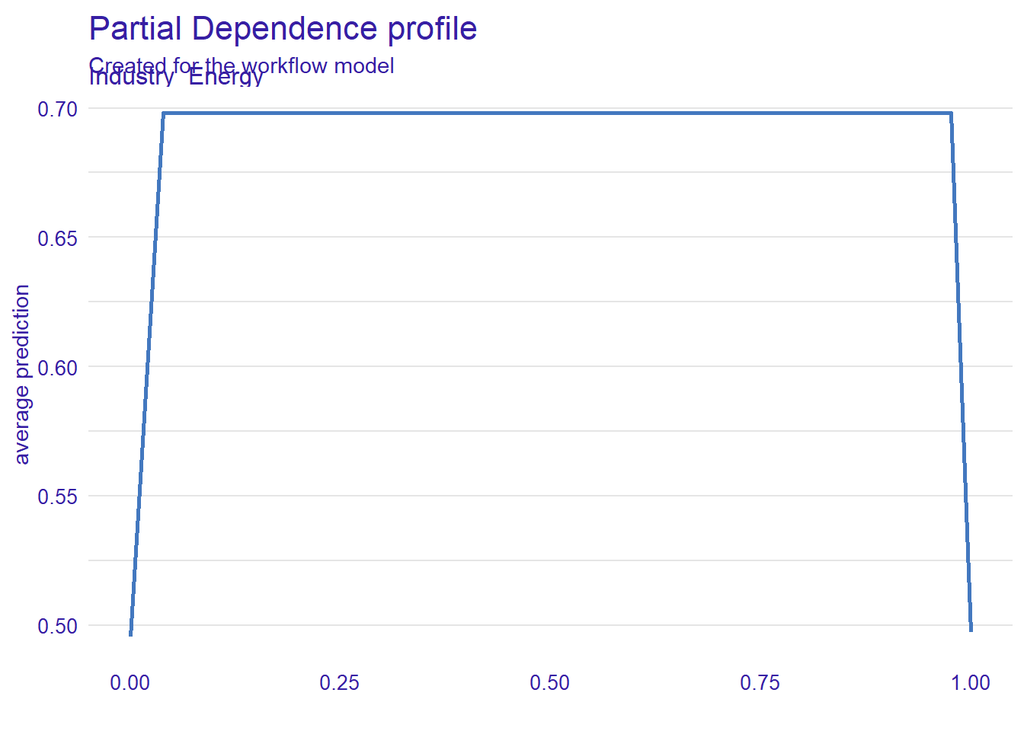

```r
plot(pdp_Data_Science_Languages)
```

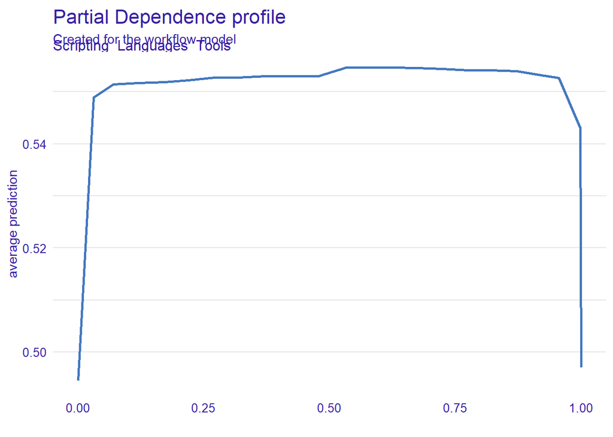

```r
plot(pdp_Script)
```

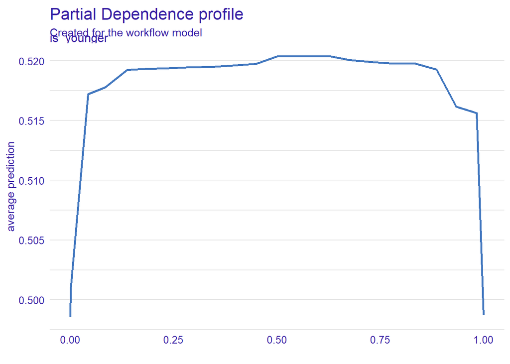

```r
plot(pdp_is_younger)
```

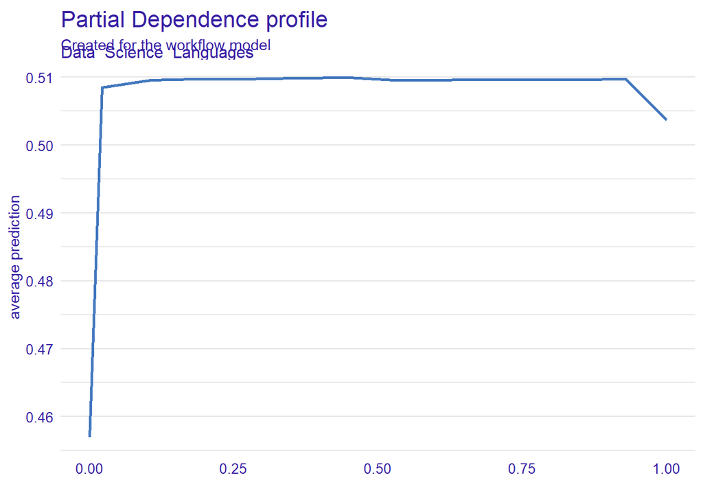

```r
plot(pdp_DS_Language)
```

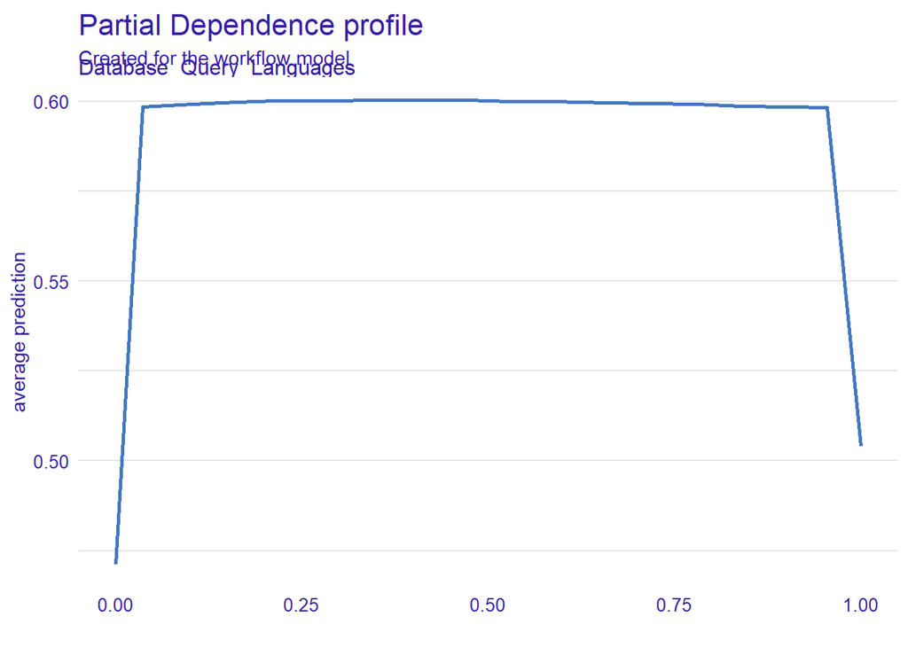

```r
plot(pdp_Data_Query_lang)
```

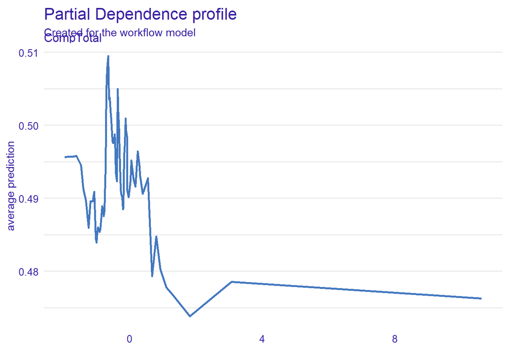

```r
plot(pdp_Comp_total)
```

# Neural Net (SoftMax) Model

The final model we will run is the neural net model utilizing softmax. This model was chosen due to its ability to model non-linear relationships and handle multi-dimensional data well. It is the goal of this model to produce a high performing model that can be used for predictive power, as we will not be able to interpret the output of the neural network due to it being a blackbox algorithim.

## Formulating the Neural Net

```r
library(caret)
library(mlbench)
library(doParallel)
library(dplyr)
library(performanceEstimation)
library(rsample)
registerDoParallel(cores = 4 )

set.seed(123)
#get index to divide data into training and test sets
index <- createDataPartition(BaggingData_copy$want_to_work_withR, p = 0.8, list = FALSE)
#create training and test sets
train_data <- BaggingData_copy[index,]
test_data <- BaggingData_copy[-index,]
#esnrue data is numeric
train_data[] <- lapply(train_data, as.numeric)

#sample 500 observations from the data randomly
sample_indices <- sample(1:nrow(train_data), 500)
Sampled_train_data <- train_data[sample_indices,]

#factor target variable into character values to work with the neural net's function
test_data$want_to_work_withR <- as.factor(ifelse(test_data$want_to_work_withR == 1, "Yes", "No"))
Sampled_train_data$want_to_work_withR <- as.factor(ifelse(Sampled_train_data$want_to_work_withR == 1, "Yes", "No"))
#display before and after SMOTE class balance
print("Before SMOTE")
```

```
## [1] "Before SMOTE"
```

```r
print(table(Sampled_train_data$want_to_work_withR))
```

```
##
##  No Yes
## 476  24
```

```r
#balance classes using SMOTE
SmoteTrainData <- smote(want_to_work_withR ~ ., data = Sampled_train_data, perc.under = 1, perc.over = 20)
print("After SMOTE")
```

```
## [1] "After SMOTE"
```

```r
print(table(SmoteTrainData$want_to_work_withR))
```

```
##
##  No Yes
## 480 504
```

```r
#Get prediction and outcome for training and test datasets
#...for train
SmoteTrainData_Pred <- SmoteTrainData[, !names(SmoteTrainData) %in% c('want_to_work_withR')]
SmoteTrainData_Outcome <- SmoteTrainData$want_to_work_withR
#...and for test
test_pred <- test_data[, !names(test_data) %in% c('want_to_work_withR')]
test_pred[] <- lapply(test_pred, as.numeric)
test_outcome <- test_data$want_to_work_withR

#set up cross validation
crtl <- trainControl(method = "repeatedcv",
                     number = 5, #do 5-fold cv
                     repeats = 5,
                     classProbs = TRUE) #report class probabilities

#this will have the model try 42 different models and chose the optimal value from them
NNGrid <- expand.grid(decay = c(0.001, 0.005),
                      size = c(15:35),
                      bag = FALSE)
#Ensure column names can work with the algorithm
names(test_pred) <- make.names(names(test_pred))
names(SmoteTrainData_Pred) <- make.names(names(SmoteTrainData_Pred))

#Train the model using our smote'd data
NN_fit <- train(SmoteTrainData_Pred, SmoteTrainData_Outcome,
                method = "avNNet", #use avnnet to prevent overfitting
                tuneGrid = NNGrid, # use grid set up earlier
                trControl = crtl, # and cross validation
                softmax = TRUE, #softmax for classification task
                #preProc = c("center", "scale"),
                trace = FALSE,
                metric = "Accuracy", #get accuracy of model
                allowParallel = TRUE, #use parallelism to improve performance
                maxit = 20) #20 iterations
```

## Predicted Outcomes and Performance Metrics

Now that our model has run, we can see how the precited outcomes compare to the actual data from our test data.

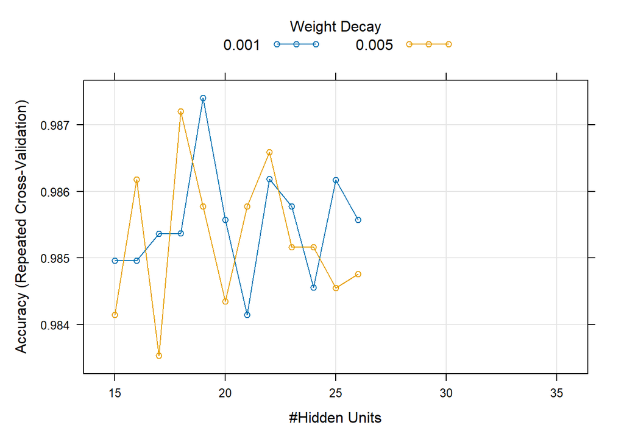

```r
set.seed(123)
plot(NN_fit)
```

```r
#get predicted outcome values
predicted_outcomes <- predict(NN_fit, test_pred)
postResample(pred= factor(predicted_outcomes), obs = factor(test_outcome))
```

```
##  Accuracy     Kappa
## 0.9282167 0.2706498
```

```r
#Output confusion  matrix
confusionMatrix <- confusionMatrix(data = factor(predicted_outcomes), reference = factor(test_outcome))
print(confusionMatrix$table)
```

```
##           Reference
## Prediction   No  Yes
##        No  2021   49
##        Yes  110   35
```

```r
#Get accuracy, F1 Score and other performance metrics
accuracy <- confusionMatrix$overall['Accuracy']
precision <- confusionMatrix$byClass['Precision']
recall <- confusionMatrix$byClass['Sensitivity']
f1_score <- 2 * (precision * recall) / (precision + recall)

print(paste("Accuracy:", round(accuracy,4)))
```

```
## [1] "Accuracy: 0.9282"
```

```r
print(paste("Precision:", round(precision,4)))
```

```
## [1] "Precision: 0.9763"
```

```r
print(paste("Recall:", round(recall,4)))
```

```
## [1] "Recall: 0.9484"
```

```r
print(paste("F1-Score:", round(f1_score,4)))
```

```
## [1] "F1-Score: 0.9622"
```

From the chart’s output, we can see that the model with 19 hidden units and a weight decay of 0.001 performed the best. Once compared to the test data, we can see that the model had an accuracy of 0.9282 and an F1-score of 0.9622. While these results are still high performing, it does not out-compete the other two models, which also offered the benefits of being more interpretable and less computationally intensive. It is for this reason that the neural net will likely not be our model of choice to predict whether a developer would be interested in R.